# Mortalidad por cáncer de pulmón en Ohio (décadas de 1960 a 1980)

# Modelado Espacial de Cáncer de Pulmón (1988)

## Selección de Variables

Para modelar los datos de área de forma adecuada, la estructura del modelo debe seguir una lógica epidemiológica de conteo:

## Evaluación y Selección de la Matriz $W$

La elección de $W$ no es arbitraria; se debe seleccionar aquella que maximice la captura de la dependencia espacial en los datos de 1988.

Según el sustento teórico, la matriz de pesos puede basarse en la similitud de una variable $X$ altamente relacionada con la respuesta $Z$. Para esto, definimos $w_{ij} = 1/(x_i - x_j)$, donde $x$ es la variable con mayor correlación con la tasa de cáncer de 1988.

Se evalúan cuatro tipos de estructuras:

- **Contigüidad Física:** Rook (Torre) y Queen (Reina).
- **Basadas en Distancia:** $k$-vecinos más cercanos con $k=3,4,5, 6,7, 8, 9, 10$.
- **Basada en Atributos:** Ponderación por diferencia de tasas históricas (similitud epidemiológica).

```
##             Matriz    Moran_I      p_valor
## 14 Variable_Weight 0.25824080 9.513234e-07
## 8             KNN5 0.06875205 2.039833e-01
## 12            KNN9 0.03099310 3.504583e-01
## 7             KNN4 0.05342814 3.577762e-01
## 9             KNN6 0.04043957 3.635502e-01
## 10            KNN7 0.02722859 4.601030e-01
## 11            KNN8 0.02270906 4.816267e-01
## 6             KNN3 0.04268369 5.052026e-01
## 1        Insumo.lw 0.02760245 5.483440e-01
## 5       Insumo.lww 0.02760245 5.483440e-01
## 3       Insumo.lwc 0.02579689 5.562978e-01
## 2       Insumo.lwb 0.02579689 5.562978e-01
## 4       Insumo.lwu 0.02579689 5.562978e-01
## 13           KNN10 0.01278658 5.724002e-01
```

```
##
##  Moran I test under randomisation
##
## data:  ohlung$tasa_mujer_88
## weights: W_seleccionada
##
## Moran I statistic standard deviate = 4.9014, p-value = 9.513e-07
## alternative hypothesis: two.sided
## sample estimates:
## Moran I statistic       Expectation          Variance
##       0.258240797      -0.011494253       0.003028488
```

El Test de Moran Global confirma la existencia de una fuerte autocorrelación espacial positiva en la tasa de cáncer de pulmón en mujeres para 1988 (I = 0.258; p-valor < 0.0001). Este resultado demuestra que la enfermedad no se distribuye de forma aleatoria en Ohio, sino que forma clústeres significativos. La intensidad de este índice, mayor a la observada en otros grupos demográficos, sugiere que los factores de riesgo subyacentes tienen una marcada estructura geoespacial o socio-ambiental.

[figure not shown]

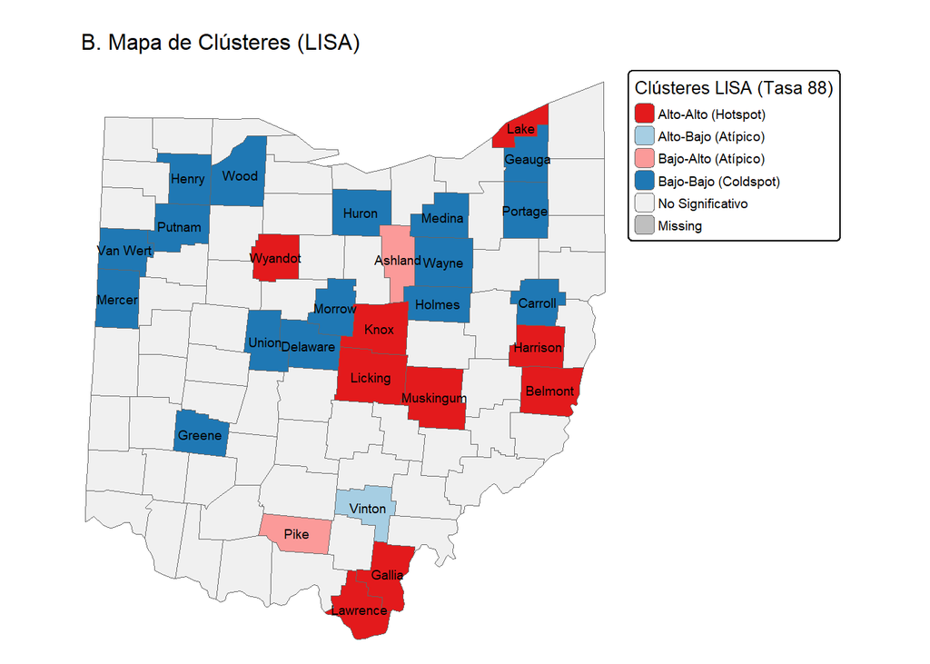

El patrón espacial es heterogéneo. Tienes un gradiente claro: un noroeste “sano” (azul) frente a un sur y sureste con focos críticos (rojo).